# Introduction

In this Data Analysis, we'll analysis a TMDB movies database file which has collected information of about 10 thousand movies which include their budget, release date, cast, director etc. The data, as provided by Udacity, is taken from below mentioned link.

https://www.google.com/url?q=https://d17h27t6h515a5.cloudfront.net/topher/2017/October/59dd1c4c_tmdb-movies/tmdb-movies.csv&sa=D&ust=1532469042115000

##### Questions that can be formulated and answered using this dataset are:-

###### 1 Which movie made the most profit?

###### 2 Which movie made the least profit (or most loss) ?

###### 3 Which is the longest and shortest movie?

###### 4 Most and least expensive Movie?

###### 5 Which movie earned most and least revenue?

###### 6 Least and most popular movie?

###### 7 Genre in which most number of movies are made?

###### 8 Movies of which genre genreate more profit and require more budget? How the trend of number of movies made shift accordingly?

###### 9 In which year, all the movies together made the most profit?

###### 10 How is the rise in profit each year, taking all the movies together?

###### 11 Which year saw most number releases?

###### 12 Actors who have appeared in atleast 50 movies?

###### 13 Actors who made most appearances since 1990,2000 and 2010 ?

###### 14 Trend in runtime of movies released after 1990?

###### 15 Month that saw highest number of releases in all of the years?

###### 16 Monthwise (of all the years ) trend of the profit made?

###### 17 Average runtime of movies released after 1990?

###### 18 Directors with most number of movies ?

###### 19 Directors with most profitable/successful movies, earning minimum 1 billion USD (since 1990) ?

###### 20 Correlation among various variables of the dataset.

### Data Wrangling

###### Let us import relevant libraries for our analysis and load the data & have a first glimpse of it. Let us also know the dimension of our dataset.

```python
import pandas as pd
import numpy as np
import matplotlib.pyplot as plt
import seaborn as sns
% matplotlib inline
```

```python
tmdb = pd.read_csv('C:/Users/shrey/Desktop/UDACITY/Project2/tmdb-movies.csv')
```

```python
tmdb.shape
```

```
(10866, 21)
```

```python
tmdb.head()
```

|  | id | imdb_id | popularity | budget | revenue | original_title | cast | homepage | director | tagline | ... | overview | runtime | genres | production_companies | release_date | vote_count | vote_average | release_year | budget_adj | revenue_adj |
| --- | --- | --- | --- | --- | --- | --- | --- | --- | --- | --- | --- | --- | --- | --- | --- | --- | --- | --- | --- | --- | --- |
| 0 | 135397 | tt0369610 | 32.985763 | 150000000 | 1513528810 | Jurassic World | Chris Pratt\|Bryce Dallas Howard\|Irrfan Khan\|Vi... | http://www.jurassicworld.com/ | Colin Trevorrow | The park is open. | ... | Twenty-two years after the events of Jurassic ... | 124 | Action\|Adventure\|Science Fiction\|Thriller | Universal Studios\|Amblin Entertainment\|Legenda... | 6/9/15 | 5562 | 6.5 | 2015 | 1.379999e+08 | 1.392446e+09 |
| 1 | 76341 | tt1392190 | 28.419936 | 150000000 | 378436354 | Mad Max: Fury Road | Tom Hardy\|Charlize Theron\|Hugh Keays-Byrne\|Nic... | http://www.madmaxmovie.com/ | George Miller | What a Lovely Day. | ... | An apocalyptic story set in the furthest reach... | 120 | Action\|Adventure\|Science Fiction\|Thriller | Village Roadshow Pictures\|Kennedy Miller Produ... | 5/13/15 | 6185 | 7.1 | 2015 | 1.379999e+08 | 3.481613e+08 |
| 2 | 262500 | tt2908446 | 13.112507 | 110000000 | 295238201 | Insurgent | Shailene Woodley\|Theo James\|Kate Winslet\|Ansel... | http://www.thedivergentseries.movie/#insurgent | Robert Schwentke | One Choice Can Destroy You | ... | Beatrice Prior must confront her inner demons ... | 119 | Adventure\|Science Fiction\|Thriller | Summit Entertainment\|Mandeville Films\|Red Wago... | 3/18/15 | 2480 | 6.3 | 2015 | 1.012000e+08 | 2.716190e+08 |
| 3 | 140607 | tt2488496 | 11.173104 | 200000000 | 2068178225 | Star Wars: The Force Awakens | Harrison Ford\|Mark Hamill\|Carrie Fisher\|Adam D... | http://www.starwars.com/films/star-wars-episod... | J.J. Abrams | Every generation has a story. | ... | Thirty years after defeating the Galactic Empi... | 136 | Action\|Adventure\|Science Fiction\|Fantasy | Lucasfilm\|Truenorth Productions\|Bad Robot | 12/15/15 | 5292 | 7.5 | 2015 | 1.839999e+08 | 1.902723e+09 |
| 4 | 168259 | tt2820852 | 9.335014 | 190000000 | 1506249360 | Furious 7 | Vin Diesel\|Paul Walker\|Jason Statham\|Michelle ... | http://www.furious7.com/ | James Wan | Vengeance Hits Home | ... | Deckard Shaw seeks revenge against Dominic Tor... | 137 | Action\|Crime\|Thriller | Universal Pictures\|Original Film\|Media Rights ... | 4/1/15 | 2947 | 7.3 | 2015 | 1.747999e+08 | 1.385749e+09 |

5 rows × 21 columns

#### Data Cleaning

##### It is important to make sure there are no double entries of any movie. If there is any, it is needful to delete them. Two (or more) movies may have same title, same director and even same cast but no two movies can have same ids.

```python
tmdb[tmdb['id'].duplicated(keep=False)]
```

|  | id | imdb_id | popularity | budget | revenue | original_title | cast | homepage | director | tagline | ... | overview | runtime | genres | production_companies | release_date | vote_count | vote_average | release_year | budget_adj | revenue_adj |
| --- | --- | --- | --- | --- | --- | --- | --- | --- | --- | --- | --- | --- | --- | --- | --- | --- | --- | --- | --- | --- | --- |
| 2089 | 42194 | tt0411951 | 0.59643 | 30000000 | 967000 | TEKKEN | Jon Foo\|Kelly Overton\|Cary-Hiroyuki Tagawa\|Ian... | NaN | Dwight H. Little | Survival is no game | ... | In the year of 2039, after World Wars destroy ... | 92 | Crime\|Drama\|Action\|Thriller\|Science Fiction | Namco\|Light Song Films | 3/20/10 | 110 | 5.0 | 2010 | 30000000.0 | 967000.0 |
| 2090 | 42194 | tt0411951 | 0.59643 | 30000000 | 967000 | TEKKEN | Jon Foo\|Kelly Overton\|Cary-Hiroyuki Tagawa\|Ian... | NaN | Dwight H. Little | Survival is no game | ... | In the year of 2039, after World Wars destroy ... | 92 | Crime\|Drama\|Action\|Thriller\|Science Fiction | Namco\|Light Song Films | 3/20/10 | 110 | 5.0 | 2010 | 30000000.0 | 967000.0 |

2 rows × 21 columns

###### Clearly, above two rows are identical. Thus, we've to remove one of them

```python
tmdb = tmdb.drop(2089)
```

```python
tmdb[tmdb['id'].duplicated(keep=False)]
```

|  | id | imdb_id | popularity | budget | revenue | original_title | cast | homepage | director | tagline | ... | overview | runtime | genres | production_companies | release_date | vote_count | vote_average | release_year | budget_adj | revenue_adj |
| --- | --- | --- | --- | --- | --- | --- | --- | --- | --- | --- | --- | --- | --- | --- | --- | --- | --- | --- | --- | --- | --- |

0 rows × 21 columns

###### Check for null values and remove columns which are not relevant for our analysis

```python
tmdb.isnull().sum()
```

```
id                         0
imdb_id                   10
popularity                 0
budget                     0
revenue                    0
original_title             0
cast                      76
homepage                7929
director                  44
tagline                 2824
keywords                1493
overview                   4
runtime                    0
genres                    23
production_companies    1030
release_date               0
vote_count                 0
vote_average               0
release_year               0
budget_adj                 0
revenue_adj                0
dtype: int64
```

```python
tmdb = tmdb.drop(['id','imdb_id','keywords','homepage','keywords','overview','production_companies','budget_adj','revenue_adj','tagline'], axis =1)
```

###### The currency of budget and revenue is not mentioned. As this is a dataset concerning Hollywood movies, we'll take all the monetary columns in US Dollars. Column names are changed accordingly.

###### Check the database for the type of column and commit required changes.

```python
tmdb.info()
```

```
<class 'pandas.core.frame.DataFrame'>
Int64Index: 10865 entries, 0 to 10865
Data columns (total 12 columns):
popularity        10865 non-null float64
budget            10865 non-null int64
revenue           10865 non-null int64
original_title    10865 non-null object
cast              10789 non-null object
director          10821 non-null object
runtime           10865 non-null int64
genres            10842 non-null object
release_date      10865 non-null object
vote_count        10865 non-null int64
vote_average      10865 non-null float64
release_year      10865 non-null int64
dtypes: float64(2), int64(5), object(5)
memory usage: 891.3+ KB
```

```python
tmdb['vote_average'] = (tmdb['vote_average']).astype(int)
```

###### Note: 'release_date' column has been dealt at a later stage of this project.

```python
tmdb.rename(columns = {'budget' : 'budget(in_USD)', 'revenue' : 'revenue(in_USD)'}, inplace = True)
```

###### Create a new column showing profit earned by each movie (in USD).

```python
tmdb['profit(in_USD)'] = tmdb['revenue(in_USD)']- tmdb['budget(in_USD)']
```

```python
tmdb.head(1)
```

|  | popularity | budget(in_USD) | revenue(in_USD) | original_title | cast | director | runtime | genres | release_date | vote_count | vote_average | release_year | profit(in_USD) |
| --- | --- | --- | --- | --- | --- | --- | --- | --- | --- | --- | --- | --- | --- |
| 0 | 32.985763 | 150000000 | 1513528810 | Jurassic World | Chris Pratt\|Bryce Dallas Howard\|Irrfan Khan\|Vi... | Colin Trevorrow | 124 | Action\|Adventure\|Science Fiction\|Thriller | 6/9/15 | 5562 | 6 | 2015 | 1363528810 |

##### Let us create two functions 'Max' and 'Min' to draw various conclusions.

```python
def Max(x):
    y = tmdb[tmdb[x] == tmdb[x].max()]
    max1 = y[['popularity','budget(in_USD)','revenue(in_USD)','original_title','runtime','genres','release_year','profit(in_USD)']]
    return max1
```

```python
def Min(x):
    z = tmdb[tmdb[x] == tmdb[x].min()]
    min2 = z[['popularity','budget(in_USD)','revenue(in_USD)','original_title','runtime','genres','release_year','profit(in_USD)']]
    return min2
```

#### 1. Movie that earned maximum profit:-

```python
Max('profit(in_USD)')
```

|  | popularity | budget(in_USD) | revenue(in_USD) | original_title | runtime | genres | release_year | profit(in_USD) |
| --- | --- | --- | --- | --- | --- | --- | --- | --- |
| 1386 | 9.432768 | 237000000 | 2781505847 | Avatar | 162 | Action\|Adventure\|Fantasy\|Science Fiction | 2009 | 2544505847 |

#### 2. Movie that earned minimum profit:-

```python
Min('profit(in_USD)')
```

|  | popularity | budget(in_USD) | revenue(in_USD) | original_title | runtime | genres | release_year | profit(in_USD) |
| --- | --- | --- | --- | --- | --- | --- | --- | --- |
| 2244 | 0.25054 | 425000000 | 11087569 | The Warrior's Way | 100 | Adventure\|Fantasy\|Action\|Western\|Thriller | 2010 | -413912431 |

#### 3. Movie with minimum runtime:

```python
Min('runtime').head(3)
```

|  | popularity | budget(in_USD) | revenue(in_USD) | original_title | runtime | genres | release_year | profit(in_USD) |
| --- | --- | --- | --- | --- | --- | --- | --- | --- |
| 92 | 1.876037 | 0 | 0 | Mythica: The Necromancer | 0 | Fantasy\|Action\|Adventure | 2015 | 0 |
| 334 | 0.357654 | 0 | 0 | Ronaldo | 0 | Documentary | 2015 | 0 |
| 410 | 0.097514 | 0 | 0 | Anarchy Parlor | 0 | Horror | 2015 | 0 |

###### We can see here that minimum runtime came out to be zero, which is not possible. Thus, we need to consider them as 'missing values'. Same holds true for Budget, Revenue and Profit columns. Hence, let us fill these zeros with missing values

```python
tmdb[['budget(in_USD)','revenue(in_USD)','profit(in_USD)', 'runtime']] = tmdb[['budget(in_USD)','revenue(in_USD)','profit(in_USD)', 'runtime']].replace(0,np.NaN)
```

```python
Min('runtime')
```

|  | popularity | budget(in_USD) | revenue(in_USD) | original_title | runtime | genres | release_year | profit(in_USD) |
| --- | --- | --- | --- | --- | --- | --- | --- | --- |
| 4883 | 0.078472 | NaN | NaN | Fresh Guacamole | 2.0 | Animation | 2012 | NaN |
| 4890 | 0.083202 | NaN | NaN | Cousin Ben Troop Screening | 2.0 | NaN | 2012 | NaN |
| 7905 | 0.647261 | NaN | NaN | The Adventures of AndrÃ© and Wally B. | 2.0 | Animation | 1984 | NaN |
| 10550 | 0.306425 | NaN | NaN | Luxo Jr. | 2.0 | Animation\|Family | 1986 | NaN |
| 10754 | 0.002757 | NaN | NaN | Bambi Meets Godzilla | 2.0 | Animation\|Comedy | 1969 | NaN |

```python
Min('runtime').shape
```

```
(5, 8)
```

```python
runtime15 = tmdb[tmdb['runtime'] < 15]
genre1 = runtime15['genres'].str.cat(sep = '|')
genre1 = pd.Series(genre1.split('|'))
genre1.value_counts(ascending = False).head(5)
```

```
Animation          92
Family             46
Comedy             41
Science Fiction    25
Fantasy            22
dtype: int64
```

```python
runtime15.shape
```

```
(132, 13)
```

###### Thus 92 out of 132 movies (almost 70%), whose runtime is less than 15 minutes, are animated movies.

#### Sidenote: If we try to drop all rows with NA values, the size of our dataset will considerably shrink, as shown below :-

```python
clean = tmdb.dropna(subset = ['budget(in_USD)', 'runtime', 'revenue(in_USD)'] )
```

```python
clean.shape
```

```
(3854, 13)
```

###### Thus, number of rows(movies) is reduced to 3854 from above 10000 earlier, which can lead us to false conclusions in questions like director with most number of movies, or actors who have featured the most, etc . So, let us not drop the rows with missing values.

###### Movie with maximum runtime:

```python
Max('runtime')
```

|  | popularity | budget(in_USD) | revenue(in_USD) | original_title | runtime | genres | release_year | profit(in_USD) |
| --- | --- | --- | --- | --- | --- | --- | --- | --- |
| 3894 | 0.006925 | NaN | NaN | The Story of Film: An Odyssey | 900.0 | Documentary | 2011 | NaN |

###### Here, the maximum runtime is 900 minutes, which can be possible if it is a documentary having multiple episodes.

#### 4. Movie with maximum budget:

```python
Max('budget(in_USD)')
```

|  | popularity | budget(in_USD) | revenue(in_USD) | original_title | runtime | genres | release_year | profit(in_USD) |
| --- | --- | --- | --- | --- | --- | --- | --- | --- |
| 2244 | 0.25054 | 425000000.0 | 11087569.0 | The Warrior's Way | 100.0 | Adventure\|Fantasy\|Action\|Western\|Thriller | 2010 | -413912431.0 |

###### Movie with minimum budget:

```python
Min('budget(in_USD)')
```

|  | popularity | budget(in_USD) | revenue(in_USD) | original_title | runtime | genres | release_year | profit(in_USD) |
| --- | --- | --- | --- | --- | --- | --- | --- | --- |
| 1151 | 0.177102 | 1.0 | NaN | Fear Clinic | 95.0 | Horror | 2014 | -1.0 |
| 2618 | 0.090186 | 1.0 | 100.0 | Lost & Found | 95.0 | Comedy\|Romance | 1999 | 99.0 |
| 3065 | 0.472691 | 1.0 | NaN | Angus, Thongs and Perfect Snogging | 100.0 | Comedy\|Drama\|Family\|Romance | 2008 | -1.0 |
| 3581 | 0.520430 | 1.0 | 1378.0 | Love, Wedding, Marriage | 90.0 | Comedy\|Romance | 2011 | 1377.0 |

```python
tmdb[tmdb['budget(in_USD)'] < 100].shape
```

```
(46, 13)
```

###### Thus, 46 movies have a budget of less than 100 USD, which seems impossible. But then, as we noticed earlier, the dataset says nothing about the currency of budget and revenue of movies. It is our assumption to take them in USD. Hence, all monetary calculations and conclusions should be considered as relative, and not absolute.

#### 5. Movie with maximum revenue:

```python
Max('revenue(in_USD)')
```

|  | popularity | budget(in_USD) | revenue(in_USD) | original_title | runtime | genres | release_year | profit(in_USD) |
| --- | --- | --- | --- | --- | --- | --- | --- | --- |
| 1386 | 9.432768 | 237000000.0 | 2.781506e+09 | Avatar | 162.0 | Action\|Adventure\|Fantasy\|Science Fiction | 2009 | 2.544506e+09 |

###### Movie(s) with minimum revenue:

```python
Min('revenue(in_USD)')
```

|  | popularity | budget(in_USD) | revenue(in_USD) | original_title | runtime | genres | release_year | profit(in_USD) |
| --- | --- | --- | --- | --- | --- | --- | --- | --- |
| 5067 | 0.462609 | 6000000.0 | 2.0 | Shattered Glass | 94.0 | Drama\|History | 2003 | -5999998.0 |
| 8142 | 0.552091 | 6000000.0 | 2.0 | Mallrats | 94.0 | Romance\|Comedy | 1995 | -5999998.0 |

###### Movie with minimum profit:

```python
Min('profit(in_USD)')
```

|  | popularity | budget(in_USD) | revenue(in_USD) | original_title | runtime | genres | release_year | profit(in_USD) |
| --- | --- | --- | --- | --- | --- | --- | --- | --- |
| 2244 | 0.25054 | 425000000.0 | 11087569.0 | The Warrior's Way | 100.0 | Adventure\|Fantasy\|Action\|Western\|Thriller | 2010 | -413912431.0 |

Interestingly, The movie with most budget is also the movie which made least profit. Thus, it makes sense that having the highest budget in all makes the film more harder to earn more profits.

###### Movie with maximum profit:

```python
Max('profit(in_USD)')
```

|  | popularity | budget(in_USD) | revenue(in_USD) | original_title | runtime | genres | release_year | profit(in_USD) |
| --- | --- | --- | --- | --- | --- | --- | --- | --- |
| 1386 | 9.432768 | 237000000.0 | 2.781506e+09 | Avatar | 162.0 | Action\|Adventure\|Fantasy\|Science Fiction | 2009 | 2.544506e+09 |

#### 6. Least popular movie:

```python
Min('popularity')
```

|  | popularity | budget(in_USD) | revenue(in_USD) | original_title | runtime | genres | release_year | profit(in_USD) |
| --- | --- | --- | --- | --- | --- | --- | --- | --- |
| 6181 | 0.000065 | NaN | NaN | North and South, Book I | 561.0 | Drama\|History\|Western | 1985 | NaN |

###### Most popular movie:

```python
Max('popularity')
```

|  | popularity | budget(in_USD) | revenue(in_USD) | original_title | runtime | genres | release_year | profit(in_USD) |
| --- | --- | --- | --- | --- | --- | --- | --- | --- |
| 0 | 32.985763 | 150000000.0 | 1.513529e+09 | Jurassic World | 124.0 | Action\|Adventure\|Science Fiction\|Thriller | 2015 | 1.363529e+09 |

#### 7. Genres in which most number of movies have been made (Top 10)

```python
genre = tmdb['genres'].str.cat(sep = '|')
genre = pd.Series(genre.split('|'))
genre.value_counts(ascending = False).head(10)
```

```
Drama              4760
Comedy             3793
Thriller           2907
Action             2384
Romance            1712
Horror             1637
Adventure          1471
Crime              1354
Family             1231
Science Fiction    1229
dtype: int64
```

#### 8. Now let's analyse which movie genre has generated more profit and how many movies are made for each profit bracket.

We'll create a function 'Above', in which we'll put the profit amount as per our choice. The output will be a graph showing number of movies made in each genre above the profit amount we've entered.

```python
def Above(Profit_value):
    profit = tmdb[tmdb['profit(in_USD)'] > Profit_value ]
    genre = profit['genres'].str.cat(sep = '|')
    genre = pd.Series(genre.split('|'))
    count = genre.value_counts(ascending = False)
    plot = count.plot.barh(color = 'red', fontsize = 13)
    plot.set(title = 'Genres in Profitable Movies')
    plot.set_xlabel('Number of Movies', color = 'black', fontsize = '13')
    plot.figure.set_size_inches(12,4.5)
    return plot
```

###### All the movies which have made profit:-

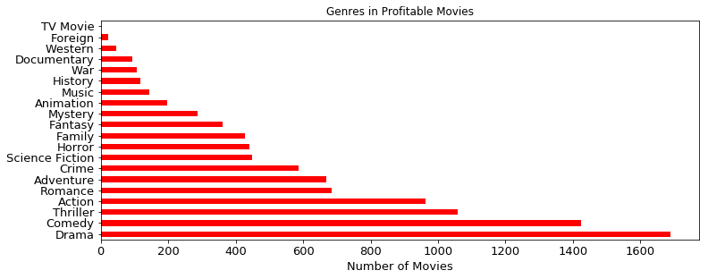

```python
Above(0)
```

###### Movies which made atleast 500 million USD :-

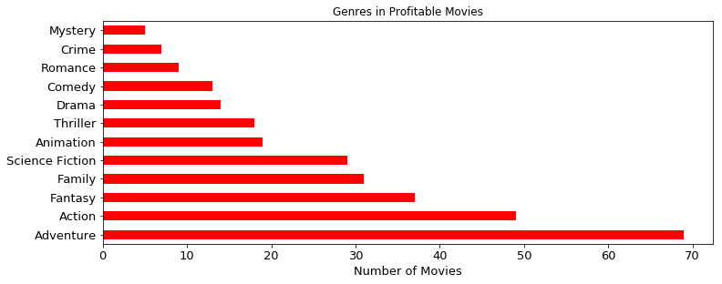

```python
Above(500000000) #500 million USD
```

###### Movies which made atleast 1 billion USD :-

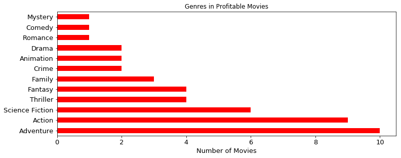

```python
Above(1000000000) #1 billion USD
```

###### Though most movies are made under the genre: 'Drama', followed by 'Comedy', the movies made under 'Action' and 'Adventure' are most profitable.

```python
def BudgetQuant(q):
    Qbudget = tmdb['budget(in_USD)'].quantile(q)
    budget = tmdb[tmdb['budget(in_USD)'] > Qbudget ]
    genre2 = budget['genres'].str.cat(sep = '|')
    genre2 = pd.Series(genre2.split('|'))
    count2 = genre2.value_counts(ascending = False)
    plot2 = count2.plot.barh(color = 'red', fontsize = 13)
    plot2.set(title = 'Genres in Movies with most budget')
    plot2.set_xlabel('Number of Movies', color = 'black', fontsize = '13')
    plot2.figure.set_size_inches(12,4.5)
    return plot2
```

###### Genres of top 70% of the movies with most budget :-

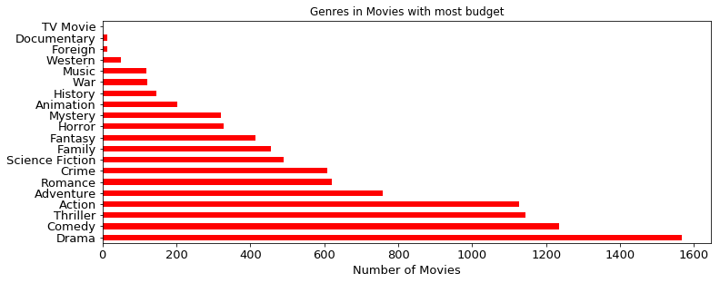

```python
BudgetQuant(0.3)
```

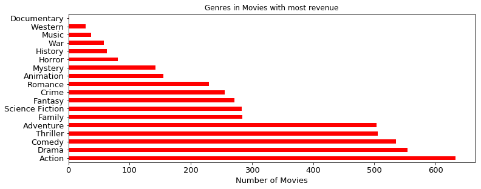

```python
RevenueQuant(0.70)
```

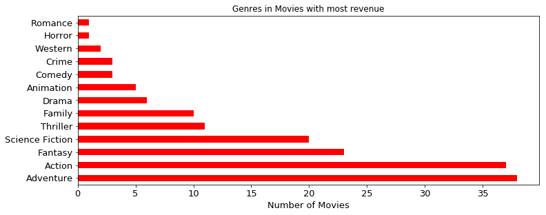

```python
RevenueQuant(0.99)
```

#### 10. Which year saw the movies making most profit?

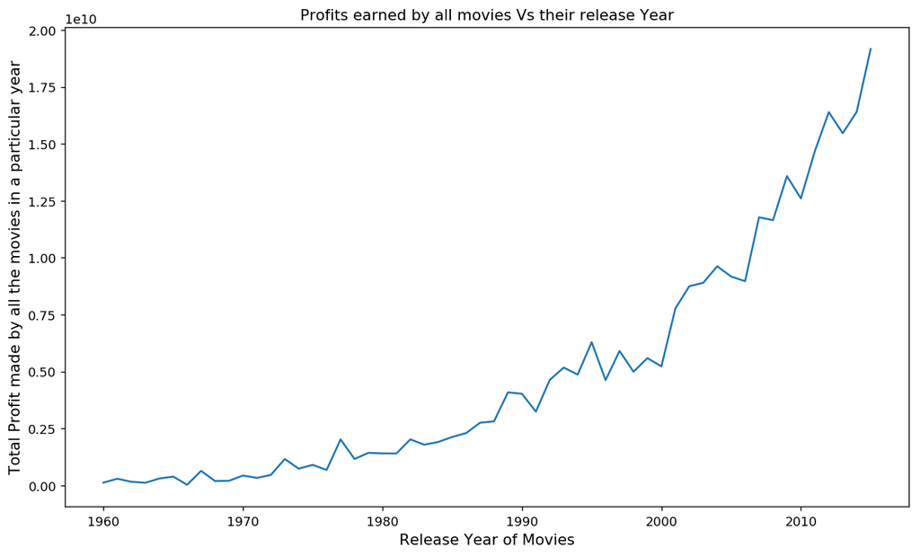

```python
year = tmdb.groupby('release_year')['profit(in_USD)'].sum()
plt.figure(figsize=(12,7), dpi = 130)
plt.xlabel('Release Year of Movies', fontsize = 12)
plt.ylabel('Total Profit made by all the movies in a particular year', fontsize = 12)
plt.title('Profits earned by all movies Vs their release Year')
plt.plot(year)
plt.show()
```

```python
year = pd.DataFrame(year)
year.tail()
```

| release_year | profit(in_USD) |
| --- | --- |
| 2011 | 1.467744e+10 |
| 2012 | 1.639434e+10 |
| 2013 | 1.546759e+10 |
| 2014 | 1.640716e+10 |
| 2015 | 1.916590e+10 |

##### 2015 was the year where movies made the highest profit of about 19+ billion dollars which released in that year.

#### 11. Let us determine which year saw most number of releases.

```python
tmdb['release_year'].value_counts().sort_values(ascending = False).head(3)
```

```
2014    700
2013    659
2015    629
Name: release_year, dtype: int64
```

#### 12. Actors/Actress who have appeared in atleast 50 movies :-

```python
cast1= tmdb['cast'].str.cat(sep = '|')
cast1 = pd.Series(cast1.split('|'))
count = cast1.value_counts(ascending = False)
count[count >= 50]
```

```
Robert De Niro       72
Samuel L. Jackson    71
Bruce Willis         62
Nicolas Cage         61
Michael Caine        53
Robin Williams       51
John Cusack          50
dtype: int64
```

#### 13. Actors who made most appearances since 1990:-

```python
def cast_after(Ryear):
    tmdb1 = tmdb[tmdb['release_year'] > Ryear]
    cast1= tmdb1['cast'].str.cat(sep = '|')
    cast1 = pd.Series(cast1.split('|'))
    count = cast1.value_counts(ascending = False)
    return count.head(5)
```

```python
cast_after(1990)
```

```
Samuel L. Jackson    71
Bruce Willis         56
Robert De Niro       54
Nicolas Cage         52
Julianne Moore       47
dtype: int64
```

###### Actors who made most appearances since 2000:-

```python
cast_after(2000)
```

```
Samuel L. Jackson    46
James Franco         40
Nicolas Cage         34
Robert De Niro       34
Colin Farrell        33
dtype: int64
```

###### Actors who made most appearances since 2010:-

```python
cast_after(2010)
```

```
James Franco         23
Danny Trejo          20
Robert De Niro       18
Jessica Chastain     17
Samuel L. Jackson    17
dtype: int64
```

### For our further analysis let us trim our dataset and consider movies which are released after year 1990 and made atleast 20 million USD of profit.

```python
tmdb90 = tmdb[tmdb['release_year'] > 1990]
```

```python
tmdb90 = tmdb90[tmdb90['profit(in_USD)'] >= 20000000] #Movies released since 1995 with min profit of 20 Million Dollars
```

#### 14. Boxplot showing runtime of movies :-

```
Text(0.5,1,'Boxplot showing runtime of movies released after year 1990')
```

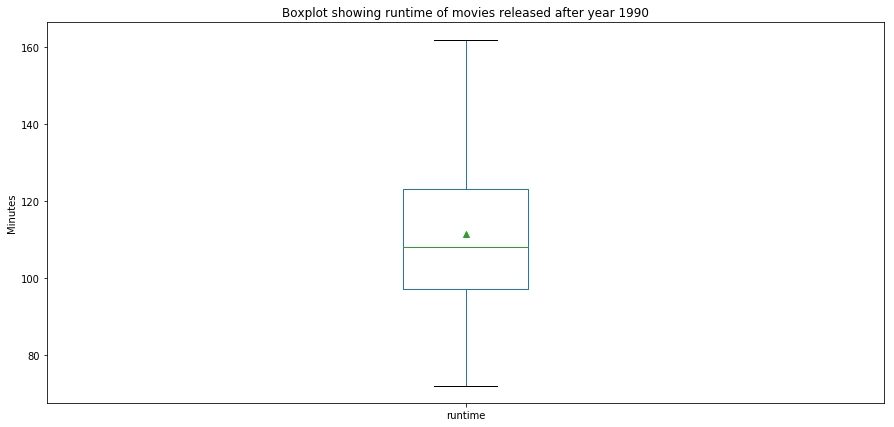

```python
plt.figure(figsize = (15,7))
tmdb90['runtime'].plot(kind='box',showfliers = False, showmeans = True)  #Excluding Outliers
plt.ylabel('Minutes', size = 10)
plt.title('Boxplot showing runtime of movies released after year 1990')
```

###### Let us see the noise of the graph using swarm plot

```
Text(0.5,1,'Swarmplot showing runtime of movies released after year 1990')
```

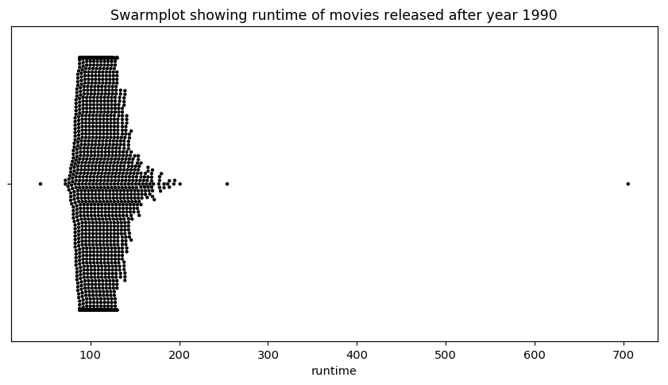

```python
plt.figure(figsize=(10,5), dpi = 105)
sns.swarmplot(tmdb90['runtime'], color = 'black', size = 3)
plt.title('Swarmplot showing runtime of movies released after year 1990')
```

###### Exclude the outlier so as to make the figure more clear

```
Text(0.5,1,'Swarmplot showing runtime of movies released after year 1990')
```

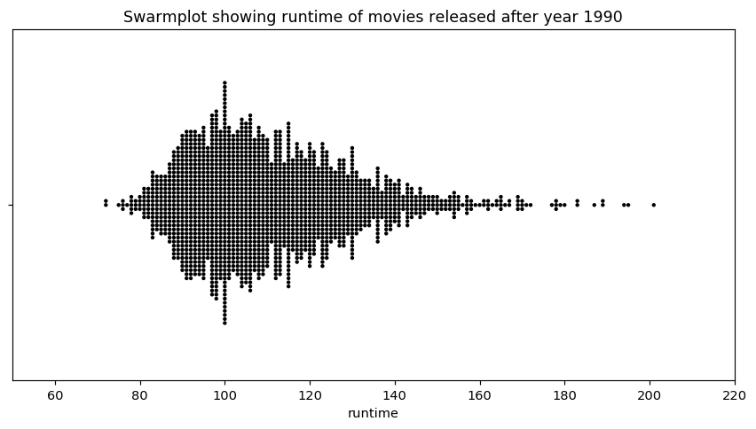

```python
plt.figure(figsize=(10,5), dpi = 105)
plt.xlim(50,220)
sns.swarmplot(tmdb90['runtime'], color = 'black', size = 3)
plt.title('Swarmplot showing runtime of movies released after year 1990')
```

#### 15. Which month released highest number of movies in all of the years?

```python
tmdb90.release_date = pd.to_datetime(tmdb90['release_date'])
```

```python
ind_date = tmdb90.set_index('release_date')
groupby_index = ind_date.groupby([(ind_date.index.month)])   #group all the data by month
monthly_count = groupby_index['profit(in_USD)'].count()  #movies released in each month
monthly_count= pd.DataFrame(monthly_count)
months = ['Jan', 'Feb', 'March', 'April', 'May', 'June', 'July', 'Aug', 'Sept', 'Oct', 'Nov', 'Dec']
```

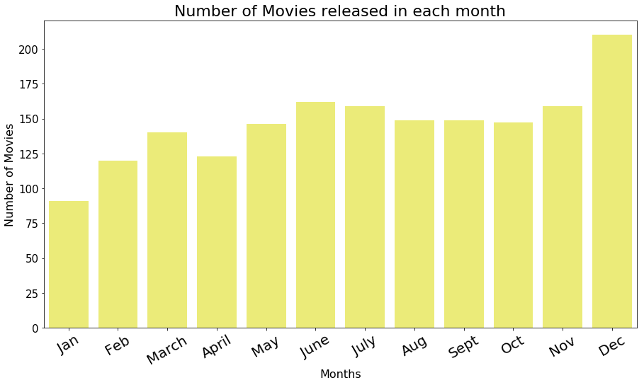

```python
plt.figure(figsize=(15,8))
count_bar = sns.barplot(x = monthly_count.index, y = monthly_count['profit(in_USD)'], data = monthly_count, color = 'yellow', alpha = 0.6)
plt.title('Number of Movies released in each month', color="black", fontsize = 22)
plt.xlabel("Months", color="black", fontsize = 16)
plt.ylabel("Number of Movies", color="black", fontsize = 16)
count_bar.tick_params(labelsize = 15, labelcolor="black")
count_bar.set_xticklabels(months, rotation = 30, size = 20)
plt.show()
```

#### 16. Which month made the most profit?

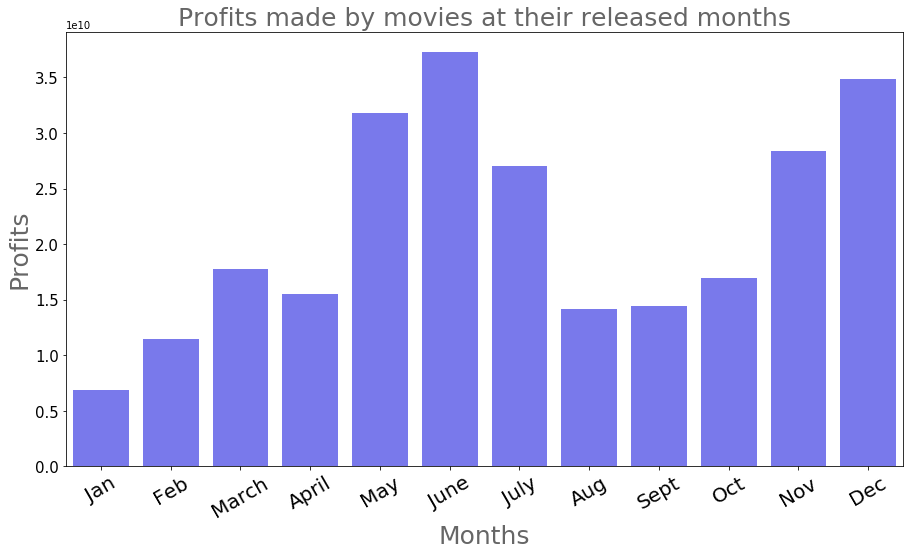

```python
plt.figure(figsize=(15,8))
monthly_profit = groupby_index['profit(in_USD)'].sum() #'profit(in_USD)' values to respective months
monthly_profit = pd.DataFrame(monthly_profit)
profit_bar = sns.barplot(x = monthly_profit.index, y = monthly_profit['profit(in_USD)'], data = monthly_profit, color = 'blue', alpha = 0.6)
plt.title('Profits made by movies at their released months', color="black", fontsize = 25, alpha = 0.6)
plt.xlabel("Months", color="black", fontsize = 25, alpha =0.6)
plt.ylabel("Profits", color="black", fontsize = 25, alpha =0.6)
profit_bar.tick_params(labelsize = 15, labelcolor="black")
profit_bar.set_xticklabels(month_list, rotation = 30, size = 20)
plt.show()
```

#### 17. Average runtime of movies released after 1990:

```python
tmdb90['runtime'].mean()
```

```
111.52193732193732
```

#### 18. Directors with most number of movies :-

```python
tmdb['director'].value_counts().head(5)
```

```
Woody Allen         45
Clint Eastwood      34
Martin Scorsese     29
Steven Spielberg    29
Ridley Scott        23
Name: director, dtype: int64
```

###### Directors with most number of movies (since 1990) :-

```python
tmdb90['director'].value_counts().head(5)
```

```
Steven Spielberg    17
Clint Eastwood      14
Ridley Scott        13
Michael Bay         11
Ron Howard          10
Name: director, dtype: int64
```

#### 19. Director with most profitable/successful movies earning minimum 1 billion USD (since 1990) :-

```python
dir = tmdb[tmdb['profit(in_USD)'] > 1000000000]
dir[['director','original_title','release_year','profit(in_USD)']].sort_values(by = ['profit(in_USD)'], ascending = False)
```

|  | director | original_title | release_year | profit(in_USD) |
| --- | --- | --- | --- | --- |
| 1386 | James Cameron | Avatar | 2009 | 2.544506e+09 |
| 3 | J.J. Abrams | Star Wars: The Force Awakens | 2015 | 1.868178e+09 |
| 5231 | James Cameron | Titanic | 1997 | 1.645034e+09 |
| 0 | Colin Trevorrow | Jurassic World | 2015 | 1.363529e+09 |
| 4 | James Wan | Furious 7 | 2015 | 1.316249e+09 |
| 4361 | Joss Whedon | The Avengers | 2012 | 1.299558e+09 |
| 3374 | David Yates | Harry Potter and the Deathly Hallows: Part 2 | 2011 | 1.202818e+09 |
| 14 | Joss Whedon | Avengers: Age of Ultron | 2015 | 1.125036e+09 |
| 5422 | Chris Buck\|Jennifer Lee | Frozen | 2013 | 1.124219e+09 |
| 8094 | Irwin Winkler | The Net | 1995 | 1.084280e+09 |
| 8 | Kyle Balda\|Pierre Coffin | Minions | 2015 | 1.082731e+09 |
| 4949 | Peter Jackson | The Lord of the Rings: The Return of the King | 2003 | 1.024889e+09 |
| 5425 | Shane Black | Iron Man 3 | 2013 | 1.015440e+09 |

```python
dir['director'].value_counts().head(3)
```

```
Joss Whedon      2
James Cameron    2
Irwin Winkler    1
Name: director, dtype: int64
```

###### Thus, if I ever 've to put my money on a movie, I'd want Joss Whedon or James Cameron to direct it.

#### 20. Correlation among various variables :-

```python
tmdb90.corr()
```

|  | popularity | budget(in_USD) | revenue(in_USD) | runtime | vote_count | vote_average | release_year | profit(in_USD) |
| --- | --- | --- | --- | --- | --- | --- | --- | --- |
| popularity | 1.000000 | 0.411134 | 0.564490 | 0.197863 | 0.741596 | 0.335976 | 0.266147 | 0.547558 |
| budget(in_USD) | 0.411134 | 1.000000 | 0.714259 | 0.318180 | 0.549979 | 0.065442 | 0.160809 | 0.575012 |
| revenue(in_USD) | 0.564490 | 0.714259 | 1.000000 | 0.244332 | 0.727351 | 0.232424 | 0.129292 | 0.982531 |
| runtime | 0.197863 | 0.318180 | 0.244332 | 1.000000 | 0.279571 | 0.370322 | -0.052054 | 0.222288 |
| vote_count | 0.741596 | 0.549979 | 0.727351 | 0.279571 | 1.000000 | 0.428665 | 0.279480 | 0.701994 |
| vote_average | 0.335976 | 0.065442 | 0.232424 | 0.370322 | 0.428665 | 1.000000 | 0.036037 | 0.250179 |
| release_year | 0.266147 | 0.160809 | 0.129292 | -0.052054 | 0.279480 | 0.036037 | 1.000000 | 0.099687 |
| profit(in_USD) | 0.547558 | 0.575012 | 0.982531 | 0.222288 | 0.701994 | 0.250179 | 0.099687 | 1.000000 |

### Conclusion :-

###### Thus, after detailed analysis of this dataset, we can concluded that, for a movie to be successful:

###### A. It should have a run time of approx 110 minutes.

###### B. It should be under the genre: drama, comedy, thriller etc, if it is a low-budget movie.

###### C. It should be under the genre: Action, Adventure etc, if it is a high-budget movie.

###### D. It should release during May, June, November or December.

###### E. If it is a short movie, animation is the preferred genre.

Notes and Limitations :-

1. Many other conclusions have been drawn and mentioned during analysis itself and thus, are not repeated here.
2. It is not guaranteed that this formula is gonna work for a successful movie, but it shows us that we have high probability of making high profits if we had similar characteristics as such. If the movie is worth, people's high expectations would lead to biased results thus resulting in high profits. We see this in real life, especially in sequels.
3. The budget and revenue columns did not have a currency specified and hence we've taken USD for all our monetary analysis.
4. Usual practice is to drop the rows with NaN values, but we've kept them so as to make our analysis as detailed as possible.
5. Attracting people towards a movie ultimately comes down to story mainly and many other important influential factors.